## Principal component analysis (week 5)

> *This week introduced dimension reduction methods such as PCA and MCA*

In this exercise, data used to calculate human development index, was used. The data includes health and life quality measures such as life expectancy and education in 155 different countries around the world. More information regarding the data is found [here](http://hdr.undp.org/en/content/human-development-report-2019-readers-guide).

```r
#Reading the data in. Changing first column to rownames
human <-read.csv("new_human_data.csv")
row.names(human) <-human[ ,1]
human <- human[ ,-1]
str(human)
```

```
## 'data.frame':    155 obs. of  8 variables:
##  $ fm2edur   : num  1.007 0.997 0.983 0.989 0.969 ...
##  $ labfm     : num  0.891 0.819 0.825 0.884 0.829 ...
##  $ lifeexp   : num  81.6 82.4 83 80.2 81.6 80.9 80.9 79.1 82 81.8 ...
##  $ expedu    : num  17.5 20.2 15.8 18.7 17.9 16.5 18.6 16.5 15.9 19.2 ...
##  $ GNI       : int  64992 42261 56431 44025 45435 43919 39568 52947 42155 32689 ...
##  $ matmortrat: int  4 6 6 5 6 7 9 28 11 8 ...
##  $ adbirthr  : num  7.8 12.1 1.9 5.1 6.2 3.8 8.2 31 14.5 25.3 ...
##  $ reprinpar : num  39.6 30.5 28.5 38 36.9 36.9 19.9 19.4 28.2 31.4 ...
```

The data has 155 observations (different countries) and 8 variables describing different characteristics of health, wellbeing, safety and life quality. Variables include fm2edur (rate of females and males with second education), GNI (gross national income), matmorthrat (maternal mortality ratio, deaths per live births). Furthermore, labfm contains the ratio of labour force participation of females and males in each country, expedu (expected years of education), where as lifeexp has the life expectancy at birth. reprinpar has information about female seats in parliament and adbirthr (births per 1,000 women ages 15–19)

```r
#Getting to know the data
summary(human)
```

```
##     fm2edur           labfm           lifeexp          expedu
##  Min.   :0.1717   Min.   :0.1857   Min.   :49.00   Min.   : 5.40
##  1st Qu.:0.7264   1st Qu.:0.5984   1st Qu.:66.30   1st Qu.:11.25
##  Median :0.9375   Median :0.7535   Median :74.20   Median :13.50
##  Mean   :0.8529   Mean   :0.7074   Mean   :71.65   Mean   :13.18
##  3rd Qu.:0.9968   3rd Qu.:0.8535   3rd Qu.:77.25   3rd Qu.:15.20
##  Max.   :1.4967   Max.   :1.0380   Max.   :83.50   Max.   :20.20
##       GNI           matmortrat        adbirthr        reprinpar
##  Min.   :   581   Min.   :   1.0   Min.   :  0.60   Min.   : 0.00
##  1st Qu.:  4198   1st Qu.:  11.5   1st Qu.: 12.65   1st Qu.:12.40
##  Median : 12040   Median :  49.0   Median : 33.60   Median :19.30
##  Mean   : 17628   Mean   : 149.1   Mean   : 47.16   Mean   :20.91
##  3rd Qu.: 24512   3rd Qu.: 190.0   3rd Qu.: 71.95   3rd Qu.:27.95
##  Max.   :123124   Max.   :1100.0   Max.   :204.80   Max.   :57.50
```

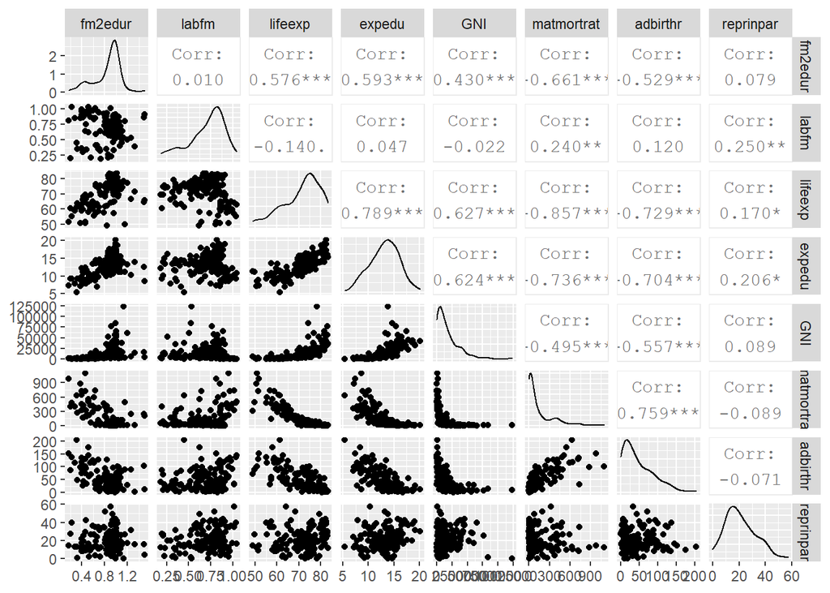

```r
ggpairs(human)
```

Only one rather normally distributed variable is found, the expedu (the expected years of education) with median 13.5 years. Variables fm2edur and labfm are left-skewed, since many countries have high female-male ratio in attending second education and working, but some countries do not. Life-expectancy has increasing density line, starting form 50 years to above 80 years. matmortrat and adbirth are heavily skewed, since many westernized countries have low ratios in these.

Then, looking how the variables correlate with each others:

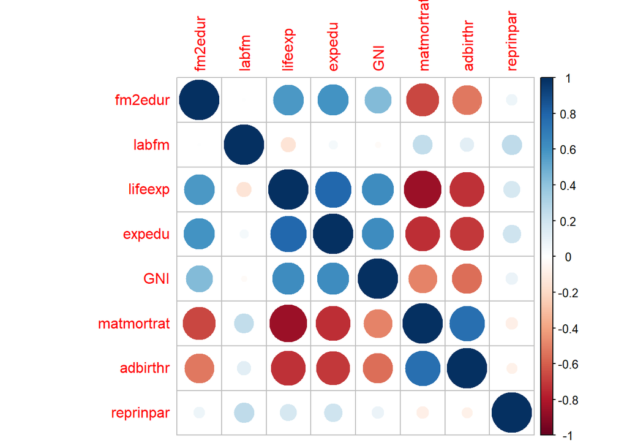

```r
#Creating correlation matrix and plotting it
cor(human) %>%
corrplot()
```

Life expectancy and expected years of education correlate highly and both of these also correlate with GNI. matmortrat and adbirthr correlate negatively with female to male education ratio and life expectancy.

Doing a PCA analysis, where 8-dimensional data is reduced to two dimensions.

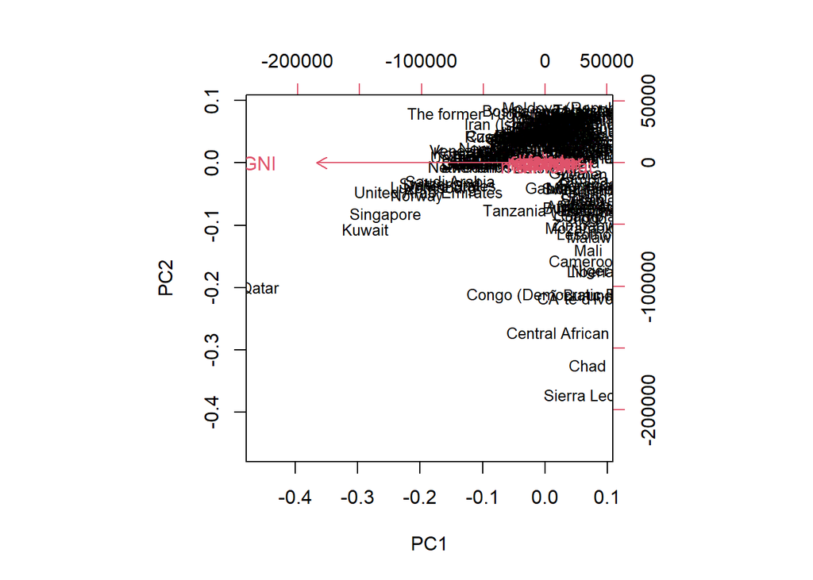

```r
#Principle component analysis
pca_human <- prcomp(human)
biplot(pca_human, choices = 1:2, cex = c(0.8, 1))
```

```r
summary(pca_human)
```

```
## Importance of components:
##                              PC1      PC2   PC3   PC4   PC5   PC6    PC7    PC8
## Standard deviation     1.854e+04 185.5219 25.19 11.45 3.766 1.566 0.1912 0.1591
## Proportion of Variance 9.999e-01   0.0001  0.00  0.00 0.000 0.000 0.0000 0.0000
## Cumulative Proportion  9.999e-01   1.0000  1.00  1.00 1.000 1.000 1.0000 1.0000
```

PCA analysis for unscaled data tells that the highest variance is explained by the first principle component, since not much variation is to be explained by PC2. GNI has longest arrow, meaning the proportion to the standard deviation of the variable. Since the angle of the variable GNI is very small (it is to same direction as PC1), is is highly correlated with PC1.

Then, the data is scaled (z-scored) and the PCA analysis is done again.

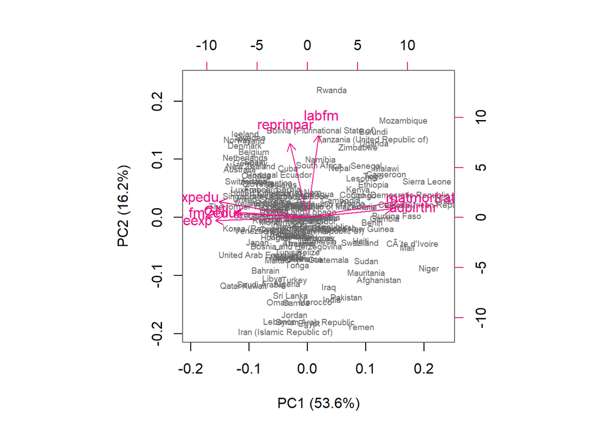

```r
scaled_human <- scale(human)
pca_human2 <- prcomp(scaled_human)
s <- summary(pca_human2)
pca_pr <- round(100*s$importance[2,], digits = 1)
pc_lab <- paste0(names(pca_pr), " (", pca_pr, "%)")

biplot(pca_human2, cex = c(0.6, 1), col = c("grey40", "deeppink2"), xlab = pc_lab[1], ylab = pc_lab[2])
```

When the data is scaled, the situation changes. PC1 explains 53.6 % of the variance in the data and PC2 16.2 %. All the variables have approximately same standard deviation, due to scaling.

mathmortrat and adbirthr point to positive end of PC1, so they correlate with each others and also PC1. Higher values of these (higher than mean values with high st.dev) are associated with higher values of PC1. Controversially, expedu, fm2edu and lifeexp are correlated to others and PC1, but higher values of these are associated with decreasing PC1 values.